# Project: TMDB movie Data Analysis

- Introduction
- Data Wrangling
- Exploratory Data Analysis
- Conclusions

## Introduction

### Dataset Description

> In this project, we need to examine the TMDB movie dataset and share what we discover. We will use Python tools such as NumPy, pandas, and Matplotlib to simplify our analysis of the TMDB movie data. This dataset has details on 10,000 movies from the Movie Database (TMDb), covering aspects like user ratings and revenue. It includes information on various fields such as ‘cast’, ‘genres’, and ‘characters’.
- **id**: Unique movie identifier.
- **imdb_id**: IMDB code specific to the movie.
- **popularity**: Metric indicating the movie's popularity.
- **budget**: Amount spent to produce the movie.
- **revenue**: Earnings from the movie.
- **original_title**: The movie's original name.
- **cast**: Leading actors involved in the movie.
- **homepage**: Official website of the movie.
- **director**: The movie's director.
- **tagline**: A catchy phrase representing the movie.
- **keywords**: Terms associated with the movie.
- **overview**: A brief summary of the movie.
- **runtime**: Total duration of the movie in minutes.
- **genres**: Categories describing the movie's style and content.
- **production_companies**: Firms that produced the movie.
- **release_date**: When the movie was first released.
- **vote_count**: Total votes received by the movie.
- **vote_average**: Average rating given to the movie.
- **release_year**: Year the movie was released.
- **budget_adj**: Movie's budget adjusted for inflation.
- **revenue_adj**: Movie's revenue adjusted for inflation.

### Question(s) for Analysis

```
Q1. What are the most common movie genres?
Q2. Who are the most cast actors?
Q3. What production company produces the most movies?
Q4. What are the top movies in terms of profit?
Q5. What are the top movies based on popularity?
Q6. What are the top movies based on viewer rating?
Q7. What are the most common keywords?
Q8. Is the budget related to a higher average vote?
Q9. what's the correlation between runtime and vote average, budget and popularity?
Q10. Who are the most successful directors?
Q11. How did the runtime of movies change over the years? What Movie has the longest runtime? what movie has the shortest runtime? what's the average movie runtime?
```

```python
#Importing Libraries
import pandas as pd
import numpy as np
import matplotlib.pyplot as plt
import seaborn as sns
%matplotlib inline
```

## Data Wrangling

- Loading the Data
- Exploring the Data
- Data Cleaning
  - Check if the data is clean, remove columns that are not needed, look for missing values (NAN values) and correct them, etc.

### Loading the Data

```python
# Load the dataset
# Importing the movie dataset
dataset_location = 'tmdb-movies.csv'
data = pd.read_csv(dataset_location)
```

### Exploring the Data

```python
# Show initial and final rows of the movie data
data.head() # Display the first few entries
```

|  | id | imdb_id | popularity | budget | revenue | original_title | cast | homepage | director | tagline | ... | overview | runtime | genres | production_companies | release_date | vote_count | vote_average | release_year | budget_adj | revenue_adj |
| --- | --- | --- | --- | --- | --- | --- | --- | --- | --- | --- | --- | --- | --- | --- | --- | --- | --- | --- | --- | --- | --- |
| 0 | 135397 | tt0369610 | 32.985763 | 150000000 | 1513528810 | Jurassic World | Chris Pratt\|Bryce Dallas Howard\|Irrfan Khan\|Vi... | http://www.jurassicworld.com/ | Colin Trevorrow | The park is open. | ... | Twenty-two years after the events of Jurassic ... | 124 | Action\|Adventure\|Science Fiction\|Thriller | Universal Studios\|Amblin Entertainment\|Legenda... | 6/9/15 | 5562 | 6.5 | 2015 | 1.379999e+08 | 1.392446e+09 |
| 1 | 76341 | tt1392190 | 28.419936 | 150000000 | 378436354 | Mad Max: Fury Road | Tom Hardy\|Charlize Theron\|Hugh Keays-Byrne\|Nic... | http://www.madmaxmovie.com/ | George Miller | What a Lovely Day. | ... | An apocalyptic story set in the furthest reach... | 120 | Action\|Adventure\|Science Fiction\|Thriller | Village Roadshow Pictures\|Kennedy Miller Produ... | 5/13/15 | 6185 | 7.1 | 2015 | 1.379999e+08 | 3.481613e+08 |
| 2 | 262500 | tt2908446 | 13.112507 | 110000000 | 295238201 | Insurgent | Shailene Woodley\|Theo James\|Kate Winslet\|Ansel... | http://www.thedivergentseries.movie/#insurgent | Robert Schwentke | One Choice Can Destroy You | ... | Beatrice Prior must confront her inner demons ... | 119 | Adventure\|Science Fiction\|Thriller | Summit Entertainment\|Mandeville Films\|Red Wago... | 3/18/15 | 2480 | 6.3 | 2015 | 1.012000e+08 | 2.716190e+08 |
| 3 | 140607 | tt2488496 | 11.173104 | 200000000 | 2068178225 | Star Wars: The Force Awakens | Harrison Ford\|Mark Hamill\|Carrie Fisher\|Adam D... | http://www.starwars.com/films/star-wars-episod... | J.J. Abrams | Every generation has a story. | ... | Thirty years after defeating the Galactic Empi... | 136 | Action\|Adventure\|Science Fiction\|Fantasy | Lucasfilm\|Truenorth Productions\|Bad Robot | 12/15/15 | 5292 | 7.5 | 2015 | 1.839999e+08 | 1.902723e+09 |
| 4 | 168259 | tt2820852 | 9.335014 | 190000000 | 1506249360 | Furious 7 | Vin Diesel\|Paul Walker\|Jason Statham\|Michelle ... | http://www.furious7.com/ | James Wan | Vengeance Hits Home | ... | Deckard Shaw seeks revenge against Dominic Tor... | 137 | Action\|Crime\|Thriller | Universal Pictures\|Original Film\|Media Rights ... | 4/1/15 | 2947 | 7.3 | 2015 | 1.747999e+08 | 1.385749e+09 |

5 rows × 21 columns

```python
# Display the last few entries of the dataset
data.tail()
```

|  | id | imdb_id | popularity | budget | revenue | original_title | cast | homepage | director | tagline | ... | overview | runtime | genres | production_companies | release_date | vote_count | vote_average | release_year | budget_adj | revenue_adj |
| --- | --- | --- | --- | --- | --- | --- | --- | --- | --- | --- | --- | --- | --- | --- | --- | --- | --- | --- | --- | --- | --- |
| 10861 | 21 | tt0060371 | 0.080598 | 0 | 0 | The Endless Summer | Michael Hynson\|Robert August\|Lord 'Tally Ho' B... | NaN | Bruce Brown | NaN | ... | The Endless Summer, by Bruce Brown, is one of ... | 95 | Documentary | Bruce Brown Films | 6/15/66 | 11 | 7.4 | 1966 | 0.000000 | 0.0 |
| 10862 | 20379 | tt0060472 | 0.065543 | 0 | 0 | Grand Prix | James Garner\|Eva Marie Saint\|Yves Montand\|Tosh... | NaN | John Frankenheimer | Cinerama sweeps YOU into a drama of speed and ... | ... | Grand Prix driver Pete Aron is fired by his te... | 176 | Action\|Adventure\|Drama | Cherokee Productions\|Joel Productions\|Douglas ... | 12/21/66 | 20 | 5.7 | 1966 | 0.000000 | 0.0 |
| 10863 | 39768 | tt0060161 | 0.065141 | 0 | 0 | Beregis Avtomobilya | Innokentiy Smoktunovskiy\|Oleg Efremov\|Georgi Z... | NaN | Eldar Ryazanov | NaN | ... | An insurance agent who moonlights as a carthie... | 94 | Mystery\|Comedy | Mosfilm | 1/1/66 | 11 | 6.5 | 1966 | 0.000000 | 0.0 |
| 10864 | 21449 | tt0061177 | 0.064317 | 0 | 0 | What's Up, Tiger Lily? | Tatsuya Mihashi\|Akiko Wakabayashi\|Mie Hama\|Joh... | NaN | Woody Allen | WOODY ALLEN STRIKES BACK! | ... | In comic Woody Allen's film debut, he took the... | 80 | Action\|Comedy | Benedict Pictures Corp. | 11/2/66 | 22 | 5.4 | 1966 | 0.000000 | 0.0 |
| 10865 | 22293 | tt0060666 | 0.035919 | 19000 | 0 | Manos: The Hands of Fate | Harold P. Warren\|Tom Neyman\|John Reynolds\|Dian... | NaN | Harold P. Warren | It's Shocking! It's Beyond Your Imagination! | ... | A family gets lost on the road and stumbles up... | 74 | Horror | Norm-Iris | 11/15/66 | 15 | 1.5 | 1966 | 127642.279154 | 0.0 |

5 rows × 21 columns

```python
# Output the total count of rows and columns in the dataset
print(f"There are {data.shape[0]:,} rows and {data.shape[1]:,} columns in the dataset.")
```

```
There are 10,866 rows and 21 columns in the dataset.
```

```python
# Generate statistical summary for the dataset's numerical columns
data.describe()
```

|  | id | popularity | budget | revenue | runtime | vote_count | vote_average | release_year | budget_adj | revenue_adj |
| --- | --- | --- | --- | --- | --- | --- | --- | --- | --- | --- |
| count | 10866.000000 | 10866.000000 | 1.086600e+04 | 1.086600e+04 | 10866.000000 | 10866.000000 | 10866.000000 | 10866.000000 | 1.086600e+04 | 1.086600e+04 |
| mean | 66064.177434 | 0.646441 | 1.462570e+07 | 3.982332e+07 | 102.070863 | 217.389748 | 5.974922 | 2001.322658 | 1.755104e+07 | 5.136436e+07 |
| std | 92130.136561 | 1.000185 | 3.091321e+07 | 1.170035e+08 | 31.381405 | 575.619058 | 0.935142 | 12.812941 | 3.430616e+07 | 1.446325e+08 |
| min | 5.000000 | 0.000065 | 0.000000e+00 | 0.000000e+00 | 0.000000 | 10.000000 | 1.500000 | 1960.000000 | 0.000000e+00 | 0.000000e+00 |
| 25% | 10596.250000 | 0.207583 | 0.000000e+00 | 0.000000e+00 | 90.000000 | 17.000000 | 5.400000 | 1995.000000 | 0.000000e+00 | 0.000000e+00 |
| 50% | 20669.000000 | 0.383856 | 0.000000e+00 | 0.000000e+00 | 99.000000 | 38.000000 | 6.000000 | 2006.000000 | 0.000000e+00 | 0.000000e+00 |
| 75% | 75610.000000 | 0.713817 | 1.500000e+07 | 2.400000e+07 | 111.000000 | 145.750000 | 6.600000 | 2011.000000 | 2.085325e+07 | 3.369710e+07 |
| max | 417859.000000 | 32.985763 | 4.250000e+08 | 2.781506e+09 | 900.000000 | 9767.000000 | 9.200000 | 2015.000000 | 4.250000e+08 | 2.827124e+09 |

1. Popularity:

Popularity scores in the dataset range widely from nearly 0 to 32.99. However, most movies have low popularity, with an average score of about 0.65.

1. Revenue:

Revenues range from 0 dollars many movies made no money to about 2.78 billion dollars. This shows that while some movies earn huge amounts, many do not make any revenue.

1. Vote Count:

Votes per movie vary greatly from 10 to 9,767, indicating that some movies are much more popular with viewers than others.

```python
# Count the unique values in each column
unique_values_count = data.nunique()
unique_values_count
```

```
id                      10865
imdb_id                 10855
popularity              10814
budget                    557
revenue                  4702
original_title          10571
cast                    10719
homepage                 2896
director                 5067
tagline                  7997
keywords                 8804
overview                10847
runtime                   247
genres                   2039
production_companies     7445
release_date             5909
vote_count               1289
vote_average               72
release_year               56
budget_adj               2614
revenue_adj              4840
dtype: int64
```

```python
# Calculate the total count of missing values per column
missing_values_count = data.isnull().sum()
missing_values_count
```

```
id                         0
imdb_id                   10
popularity                 0
budget                     0
revenue                    0
original_title             0
cast                      76
homepage                7930
director                  44
tagline                 2824
keywords                1493
overview                   4
runtime                    0
genres                    23
production_companies    1030
release_date               0
vote_count                 0
vote_average               0
release_year               0
budget_adj                 0
revenue_adj                0
dtype: int64
```

Columns with many unique values compared to the number of rows are high-cardinality categorical features. Columns with few unique values are likely categorical.

```python
# Display the data types and check for missing values in each column
data.info()
```

```
<class 'pandas.core.frame.DataFrame'>
RangeIndex: 10866 entries, 0 to 10865
Data columns (total 21 columns):
 #   Column                Non-Null Count  Dtype
---  ------                --------------  -----
 0   id                    10866 non-null  int64
 1   imdb_id               10856 non-null  object
 2   popularity            10866 non-null  float64
 3   budget                10866 non-null  int64
 4   revenue               10866 non-null  int64
 5   original_title        10866 non-null  object
 6   cast                  10790 non-null  object
 7   homepage              2936 non-null   object
 8   director              10822 non-null  object
 9   tagline               8042 non-null   object
 10  keywords              9373 non-null   object
 11  overview              10862 non-null  object
 12  runtime               10866 non-null  int64
 13  genres                10843 non-null  object
 14  production_companies  9836 non-null   object
 15  release_date          10866 non-null  object
 16  vote_count            10866 non-null  int64
 17  vote_average          10866 non-null  float64
 18  release_year          10866 non-null  int64
 19  budget_adj            10866 non-null  float64
 20  revenue_adj           10866 non-null  float64
dtypes: float64(4), int64(6), object(11)
memory usage: 1.7+ MB
```

Some columns have missing values: cast, homepage, director, tagline, keywords, overview, genres, and production_companies. All data types are correct except for release_date and release_year. I will keep the datatype of release_year as it is. The release_date will be dropped later in the analysis because it is not important for this study.

### Data Cleaning

- Based on my observations from the first 5 rows, and from previous datasets we need to do the following:
  1. The columns id, imdb_id, homepage, budget_adj, revenue adj are useless, hence, we need to delete them
  2. remove dublicates
  3. check for NAN values
  4. replace null values with NAN

#### Dropping Unimportant Columns, duplicates, and null values.

I will drop the following columns because they are not important or needed for this analysis: 'id', 'imdb_id', 'homepage', 'tagline', 'overview', 'vote_count', 'budget_adj', and 'revenue_adj'.

```python
# Remove columns that are not significant for our analysis
columns_to_drop = ['id', 'imdb_id', 'homepage', 'tagline', 'overview', 'vote_count', 'budget_adj', 'revenue_adj', 'release_date']
data.drop(columns=columns_to_drop, axis=1, inplace=True)

# Display the first few rows after dropping columns
data.head()
```

|  | popularity | budget | revenue | original_title | cast | director | keywords | runtime | genres | production_companies | vote_average | release_year |
| --- | --- | --- | --- | --- | --- | --- | --- | --- | --- | --- | --- | --- |
| 0 | 32.985763 | 150000000 | 1513528810 | Jurassic World | Chris Pratt\|Bryce Dallas Howard\|Irrfan Khan\|Vi... | Colin Trevorrow | monster\|dna\|tyrannosaurus rex\|velociraptor\|island | 124 | Action\|Adventure\|Science Fiction\|Thriller | Universal Studios\|Amblin Entertainment\|Legenda... | 6.5 | 2015 |
| 1 | 28.419936 | 150000000 | 378436354 | Mad Max: Fury Road | Tom Hardy\|Charlize Theron\|Hugh Keays-Byrne\|Nic... | George Miller | future\|chase\|post-apocalyptic\|dystopia\|australia | 120 | Action\|Adventure\|Science Fiction\|Thriller | Village Roadshow Pictures\|Kennedy Miller Produ... | 7.1 | 2015 |
| 2 | 13.112507 | 110000000 | 295238201 | Insurgent | Shailene Woodley\|Theo James\|Kate Winslet\|Ansel... | Robert Schwentke | based on novel\|revolution\|dystopia\|sequel\|dyst... | 119 | Adventure\|Science Fiction\|Thriller | Summit Entertainment\|Mandeville Films\|Red Wago... | 6.3 | 2015 |
| 3 | 11.173104 | 200000000 | 2068178225 | Star Wars: The Force Awakens | Harrison Ford\|Mark Hamill\|Carrie Fisher\|Adam D... | J.J. Abrams | android\|spaceship\|jedi\|space opera\|3d | 136 | Action\|Adventure\|Science Fiction\|Fantasy | Lucasfilm\|Truenorth Productions\|Bad Robot | 7.5 | 2015 |
| 4 | 9.335014 | 190000000 | 1506249360 | Furious 7 | Vin Diesel\|Paul Walker\|Jason Statham\|Michelle ... | James Wan | car race\|speed\|revenge\|suspense\|car | 137 | Action\|Crime\|Thriller | Universal Pictures\|Original Film\|Media Rights ... | 7.3 | 2015 |

```python
# Calculate the number of duplicate rows in the dataset
duplicate_entries_count = data.duplicated().sum()
duplicate_entries_count
```

```
1
```

```python
# Remove duplicate rows from the dataset
data.drop_duplicates(inplace=True)

# Verify that all duplicate rows have been removed
remaining_duplicates = data.duplicated().sum()
remaining_duplicates
```

```
0
```

```python
# Drop rows with missing values in critical columns
data = data.dropna(subset=['genres','director', 'cast'])
```

```python
data.info()
```

```
<class 'pandas.core.frame.DataFrame'>
Index: 10731 entries, 0 to 10865
Data columns (total 12 columns):
 #   Column                Non-Null Count  Dtype
---  ------                --------------  -----
 0   popularity            10731 non-null  float64
 1   budget                10731 non-null  int64
 2   revenue               10731 non-null  int64
 3   original_title        10731 non-null  object
 4   cast                  10731 non-null  object
 5   director              10731 non-null  object
 6   keywords              9306 non-null   object
 7   runtime               10731 non-null  int64
 8   genres                10731 non-null  object
 9   production_companies  9772 non-null   object
 10  vote_average          10731 non-null  float64
 11  release_year          10731 non-null  int64
dtypes: float64(2), int64(4), object(6)
memory usage: 1.1+ MB
```

```python
# Convert specified object type columns to string type
cols_to_convert = ['production_companies', 'genres', 'keywords', 'director', 'original_title', 'cast']
data[cols_to_convert] = data[cols_to_convert].astype(str)
```

```python
data.info()
```

```
<class 'pandas.core.frame.DataFrame'>
Index: 10731 entries, 0 to 10865
Data columns (total 12 columns):
 #   Column                Non-Null Count  Dtype
---  ------                --------------  -----
 0   popularity            10731 non-null  float64
 1   budget                10731 non-null  int64
 2   revenue               10731 non-null  int64
 3   original_title        10731 non-null  object
 4   cast                  10731 non-null  object
 5   director              10731 non-null  object
 6   keywords              10731 non-null  object
 7   runtime               10731 non-null  int64
 8   genres                10731 non-null  object
 9   production_companies  10731 non-null  object
 10  vote_average          10731 non-null  float64
 11  release_year          10731 non-null  int64
dtypes: float64(2), int64(4), object(6)
memory usage: 1.1+ MB
```

Changing columns to string makes sure all entries, even numbers and NaN values, are treated as strings in those columns.

The keywords and production_companies columns have null values, but since I might not need these columns, I'll leave them as they are (impute them).

```python
# Save the data before removing 'production_companies' and 'keywords' columns
# These columns will be used only in two specific research questions

# Create a copy of the data for company-related analysis
company_data = data.copy()

# Drop the 'keywords' column from the company_data
company_data.drop('keywords', axis=1, inplace=True)

# Remove rows with missing values in the 'production_companies' column
company_data.dropna(subset=['production_companies'], inplace=True)

# Remove NaN values from company_data
company_data = company_data[company_data != 'nan']

#########################################################################

# Create a copy of the data
keywords_data = data.copy()

# Drop the 'production_companies' column from the keywords_data
keywords_data.drop('production_companies', axis=1, inplace=True)

# Remove rows with missing values in the 'keywords' column
keywords_data.dropna(subset=['keywords'], inplace=True)
# Remove NaN values from keywords_data
keywords_data = keywords_data[keywords_data != 'nan']
```

```python
# Verify the changes by checking for missing values in the modified datasets
print("Missing values in company_data:")
print(company_data.isnull().sum())

print("\nMissing values in keywords_data:")
print(keywords_data.isnull().sum())
```

```
Missing values in company_data:
popularity                0
budget                    0
revenue                   0
original_title            0
cast                      0
director                  0
runtime                   0
genres                    0
production_companies    959
vote_average              0
release_year              0
dtype: int64

Missing values in keywords_data:
popularity           0
budget               0
revenue              0
original_title       0
cast                 0
director             0
keywords          1425
runtime              0
genres               0
vote_average         0
release_year         0
dtype: int64
```

We save the data before removing the 'production_companies' and 'keywords' columns. These columns will be used only for two research questions. They are removed because they have many missing values. Dropping these rows would affect other columns, so we will handle the questions with the missing rows imputed.

```python
data.drop(['production_companies','keywords'], axis = 1, inplace=True)
```

```python
#Number of missing values in each column.
data.isnull().sum()
```

```
popularity        0
budget            0
revenue           0
original_title    0
cast              0
director          0
runtime           0
genres            0
vote_average      0
release_year      0
dtype: int64
```

```python
# Remove NaN values
data = data[data != 'nan']
```

### Review dataset

```python
# Display the first 10 rows of the dataset to get an overview
data.head(10)
```

|  | popularity | budget | revenue | original_title | cast | director | runtime | genres | vote_average | release_year |
| --- | --- | --- | --- | --- | --- | --- | --- | --- | --- | --- |
| 0 | 32.985763 | 150000000 | 1513528810 | Jurassic World | Chris Pratt\|Bryce Dallas Howard\|Irrfan Khan\|Vi... | Colin Trevorrow | 124 | Action\|Adventure\|Science Fiction\|Thriller | 6.5 | 2015 |
| 1 | 28.419936 | 150000000 | 378436354 | Mad Max: Fury Road | Tom Hardy\|Charlize Theron\|Hugh Keays-Byrne\|Nic... | George Miller | 120 | Action\|Adventure\|Science Fiction\|Thriller | 7.1 | 2015 |
| 2 | 13.112507 | 110000000 | 295238201 | Insurgent | Shailene Woodley\|Theo James\|Kate Winslet\|Ansel... | Robert Schwentke | 119 | Adventure\|Science Fiction\|Thriller | 6.3 | 2015 |
| 3 | 11.173104 | 200000000 | 2068178225 | Star Wars: The Force Awakens | Harrison Ford\|Mark Hamill\|Carrie Fisher\|Adam D... | J.J. Abrams | 136 | Action\|Adventure\|Science Fiction\|Fantasy | 7.5 | 2015 |
| 4 | 9.335014 | 190000000 | 1506249360 | Furious 7 | Vin Diesel\|Paul Walker\|Jason Statham\|Michelle ... | James Wan | 137 | Action\|Crime\|Thriller | 7.3 | 2015 |
| 5 | 9.110700 | 135000000 | 532950503 | The Revenant | Leonardo DiCaprio\|Tom Hardy\|Will Poulter\|Domhn... | Alejandro González Iñárritu | 156 | Western\|Drama\|Adventure\|Thriller | 7.2 | 2015 |
| 6 | 8.654359 | 155000000 | 440603537 | Terminator Genisys | Arnold Schwarzenegger\|Jason Clarke\|Emilia Clar... | Alan Taylor | 125 | Science Fiction\|Action\|Thriller\|Adventure | 5.8 | 2015 |
| 7 | 7.667400 | 108000000 | 595380321 | The Martian | Matt Damon\|Jessica Chastain\|Kristen Wiig\|Jeff ... | Ridley Scott | 141 | Drama\|Adventure\|Science Fiction | 7.6 | 2015 |
| 8 | 7.404165 | 74000000 | 1156730962 | Minions | Sandra Bullock\|Jon Hamm\|Michael Keaton\|Allison... | Kyle Balda\|Pierre Coffin | 91 | Family\|Animation\|Adventure\|Comedy | 6.5 | 2015 |
| 9 | 6.326804 | 175000000 | 853708609 | Inside Out | Amy Poehler\|Phyllis Smith\|Richard Kind\|Bill Ha... | Pete Docter | 94 | Comedy\|Animation\|Family | 8.0 | 2015 |

```python
# Get the dimensions of the dataset (number of rows and columns)
dataset_dimensions = data.shape

# Display the dimensions
dataset_dimensions
```

```
(10731, 10)
```

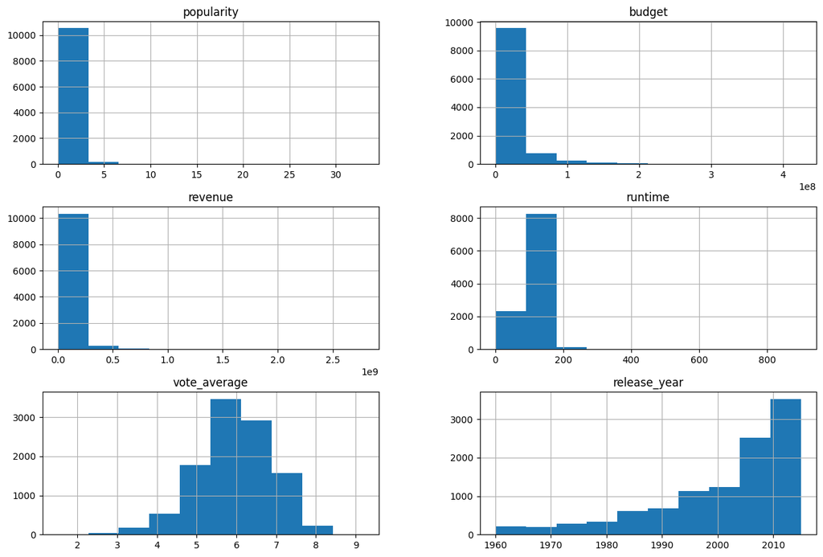

```python
# Plot the distribution of the numerical features in the dataset
data.hist(figsize=(15,10));
```

## Exploratory Data Analysis

- Relationship Between Independent Features
- Total Number of Movies Produced by Year
- Total Number of Movies Produced by Genre

> Now that we've cleaned the data, we can start exploring it. In this section, we'll calculate statistics and make visualizations to answer the research questions from the Introduction.

### General Questions

#### Q1. What is the relationship Between Independent Features

```python
# Plots the relationship between two variables as a scatter plot.

#     Args:
#     data : DataFrame containing the data.
#     x_axis : Column name for the x-axis.
#     y_axis : Column name for the y-axis (default is 'revenue').
#     plot_kind : Type of plot (default is 'scatter').
#     title_prefix : Prefix for the title (default is 'Relationship between').

def plot_relationship(data, x_axis, y_axis='revenue', plot_kind='scatter', title_prefix='Relationship between'):
    data.plot(x=x_axis, y=y_axis, kind=plot_kind)
    plt.title(f'{title_prefix} {x_axis.capitalize()} and {y_axis.capitalize()}')
    plt.show()
```

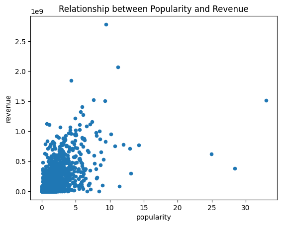

```python
# #Relationship between popularity and revenue.


plot_relationship(data, 'popularity')
```

1. There is some positive correlation between popularity and revenue as this plot shows that the correlation is not that strong. This will be investigated further later in the analysis.
2. X-Axis (Popularity): Represents the independent variable, popularity. This axis measures how popular the instances (e.g., movies) are, with values ranging from 0 to above 30.
3. Y-Axis (Revenue): Represents the dependent variable, revenue. This axis measures the revenue generated by the instances, with values up to around 2.5 billion.

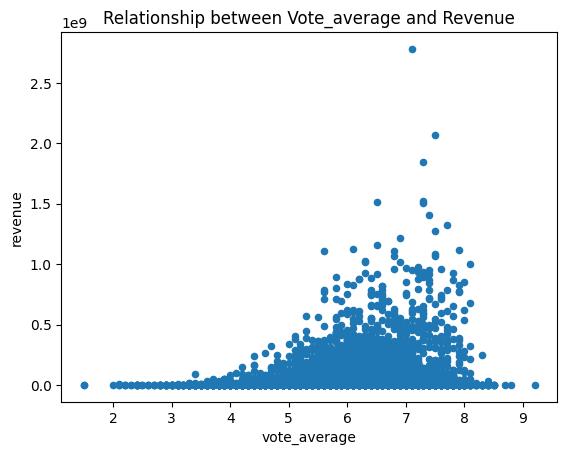

```python
# #Relationship between vote_average and revenue.

plot_relationship(data, 'vote_average')
```

1. There is some positive correlation between vote_average and revenue. This will be investigated further later in the analysis.
2. X-Axis (Vote Average): Represents the independent variable, vote average. This axis measures the average rating given to the instances (e.g., movies), with values ranging from 2 to 9.
3. Y-Axis (Revenue): Represents the dependent variable, revenue. This axis measures the revenue generated by the instances, with values up to around 2.5 billion.

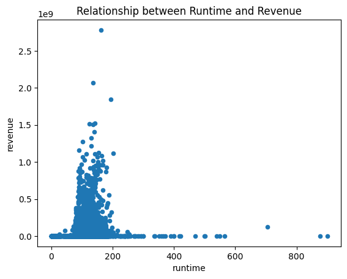

```python
# #Relationship between runtime and revenue.

plot_relationship(data, 'runtime')
```

1. There is no correlation between runtime and revenue. This will be investigated further later in the analysis.
2. X-Axis (Runtime): Represents the independent variable, runtime. This axis measures the duration of the instances (e.g., movies) in minutes, with values ranging from 0 to over 800 minutes.
3. Y-Axis (Revenue): Represents the dependent variable, revenue. This axis measures the revenue generated by the instances, with values up to around 2.5 billion.

#### Q2. What is the total Number of Movies Produced by Year?

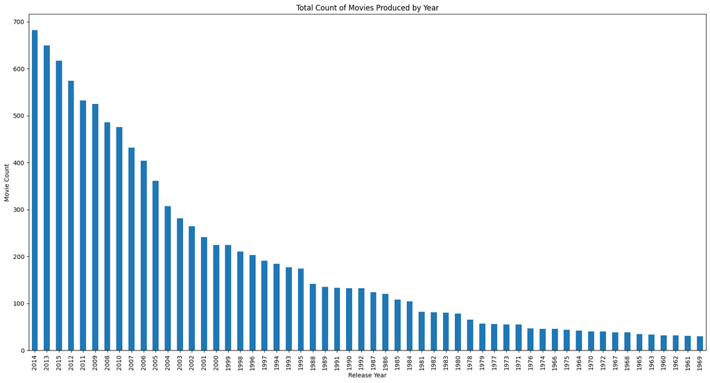

```python
#Value counts of movies for each year.
data.release_year.value_counts().plot(kind = 'bar', figsize = (20, 10));
plt.xlabel('Release Year');
plt.ylabel('Movie Count')
plt.title('Total Count of Movies Produced by Year');
```

### Research Questions

#### Research Question 1: What are the most common movie genres?

> First thing we notice how the genres column is pipe separated and when we tried to check for unique values in returned all genres at once so we need to separate them

```python
genres = pd.Series(data['genres'].str.split('|', expand=True).stack())
genre_counts = genres.value_counts()
genre_counts
```

```
Drama              4746
Comedy             3775
Thriller           2902
Action             2376
Romance            1708
Horror             1636
Adventure          1465
Crime              1353
Science Fiction    1221
Family             1214
Fantasy             908
Mystery             808
Animation           664
Documentary         470
Music               399
History             330
War                 268
Foreign             184
Western             164
TV Movie            162
Name: count, dtype: int64
```

##### Conclusion:

> Drama movies are the most common genre followed by comedy and Thriller, Tv movies and Western movies are the least common genres

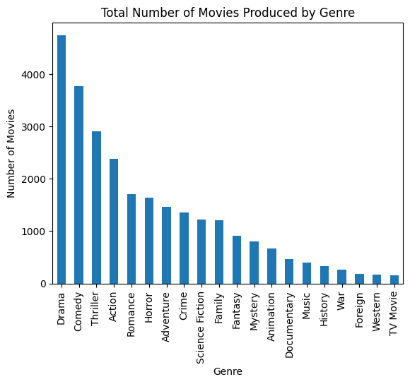

```python
#get the visualization of this conclusion:
genres =  pd.Series(data['genres'].str.split('|', expand=True).stack()).value_counts()
genre_counts = genres
genre_counts.plot(kind='bar', title='Total Number of Movies Produced by Genre')

# Show the plot
plt.xlabel('Genre')
plt.ylabel('Number of Movies')
plt.show()
```

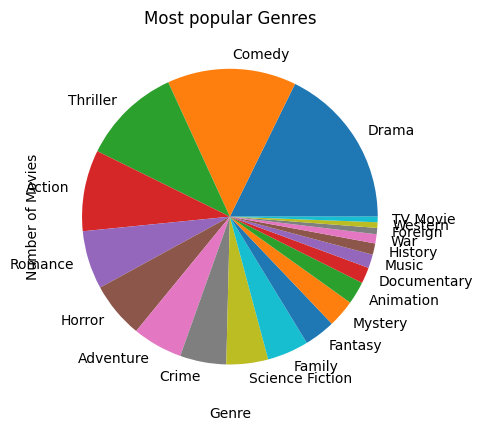

```python
plotpie= genre_counts.plot.pie()
plotpie.set(title = 'Most popular Genres')
plotpie.set_xlabel('Genre')
plotpie.set_ylabel('Number of Movies')
plt.show()
```

#### Research Question 2: Who are the most cast actors?

> Notice that the cast column is separated the same way as the genres column so it's basically the same process

```python
# Split the cast column and count occurrences

cast_split = pd.Series(data['cast'].str.split('|', expand=True).stack())

# Count occurrences
cast_count = cast_split.value_counts()
print(cast_count.head(10))
```

```
Robert De Niro       72
Samuel L. Jackson    71
Bruce Willis         62
Nicolas Cage         61
Michael Caine        53
Robin Williams       51
John Cusack          50
John Goodman         49
Morgan Freeman       49
Liam Neeson          48
Name: count, dtype: int64
```

##### conclusion:

> Robert De Niro is the most cast actor with 72 movies followed by Samuel L. Jackson with 71 movies, Bruce Willis comes third with 62 movies... Now we find the most common genre for each of these actors as well as the average rate for the movies they appeared in

> Here we can get the top 10 actors based on number of appearances in movies:

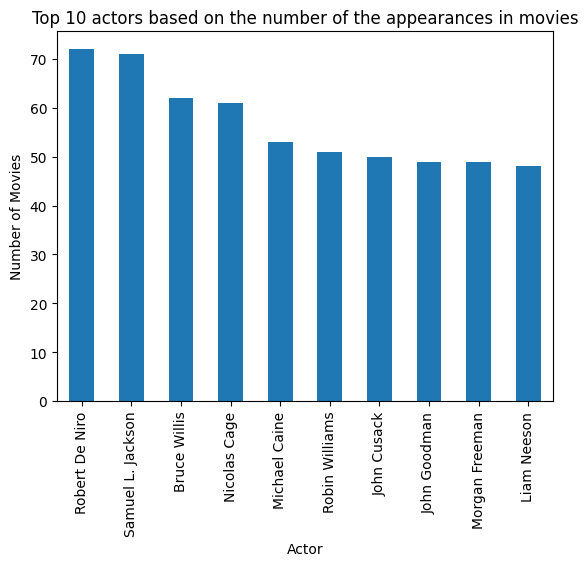

```python
top_cast_counts = cast_count.head(10)
top_cast_counts.plot(kind='bar', title='Top 10 actors based on the number of the appearances in movies')
plt.xlabel('Actor')
plt.ylabel('Number of Movies')
plt.show()
```

##### Conclusion:

> Top 3 actors based on movie appearance are Robert De Niro, Samuel L.Jackson and Bruce Willis, we can now see a detailed visualization of the movies of the most popular actor

##### visualization of Robert De Niro movies:

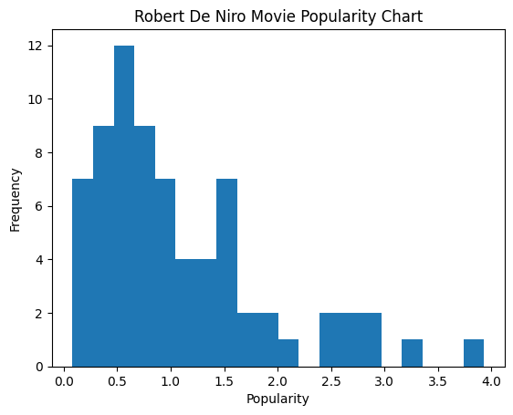

```python
# Filter the dataset for movies featuring Robert De Niro
filter1 = data[data['cast'].str.contains('Robert De Niro', na=False)]

# 1. Histogram of Robert De Niro movie popularity
filter1['popularity'].plot(kind='hist', title='Robert De Niro Movie Popularity Chart', bins=20)
plt.xlabel('Popularity')
plt.ylabel('Frequency')
plt.show()
```

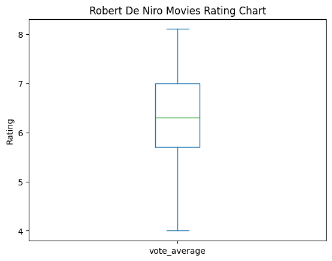

```python
# 2. Box plot of Robert De Niro movie ratings
filter1['vote_average'].plot(kind='box', title='Robert De Niro Movies Rating Chart')
plt.ylabel('Rating')
plt.show()
```

```python
# Convert vote_average and runtime to Numpy arrays
vote_average_array = filter1['vote_average'].to_numpy()
runtime_array = filter1['runtime'].to_numpy()
```

```python
# 3. Mean vote average of Robert De Niro movies using Numpy
mean_vote_average = np.mean(vote_average_array)
print(f"Mean vote average of Robert De Niro movies: {mean_vote_average}")
```

```
Mean vote average of Robert De Niro movies: 6.330555555555555
```

```python
# 4. Mean runtime of Robert De Niro movies using Numpy
mean_runtime = np.mean(runtime_array)
print(f"Mean runtime of Robert De Niro movies: {mean_runtime} minutes")
```

```
Mean runtime of Robert De Niro movies: 114.98611111111111 minutes
```

#### Research Question 3: What production company produces the most movies?

```python
# Split the cast column and count occurrences

company_split = pd.Series(company_data['production_companies'].str.split('|', expand=True).stack())

# Count occurrences
company_count  = company_split.value_counts()
print(company_count.head(10))
```

```
Universal Pictures                        522
Warner Bros.                              509
Paramount Pictures                        431
Twentieth Century Fox Film Corporation    282
Columbia Pictures                         272
New Line Cinema                           219
Metro-Goldwyn-Mayer (MGM)                 218
Walt Disney Pictures                      213
Touchstone Pictures                       178
Columbia Pictures Corporation             160
Name: count, dtype: int64
```

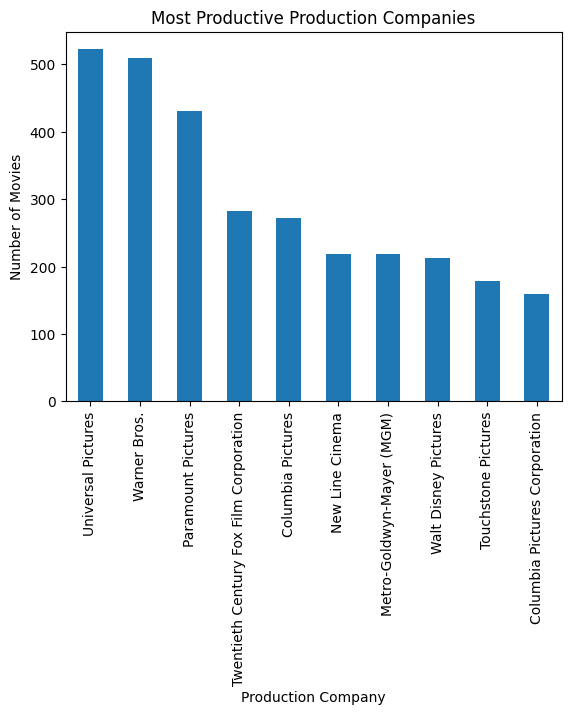

```python
# Plot the most common production companies
top_company_counts = company_count.head(10)
top_company_counts.plot(kind='bar', title='Most Productive Production Companies')
plt.xlabel('Production Company')
plt.ylabel('Number of Movies')
plt.show()
```

##### Conclusion:

```
Universal Pictures is the company that produces most movies followed by Warner Bros. in 2nd place and Paramount pictures in 3rd
```

#### Research Question 4: What are the top movies in terms of profit?

##### Convert budget and revenue to numeric values (if not already)

```python
# # Convert budget and revenue to numeric values (if not already)
# data['budget'] = pd.to_numeric(data['budget'], errors='coerce')
# data['revenue'] = pd.to_numeric(data['revenue'], errors='coerce')


def convert_to_numeric(data, columns):
    # Converts specified columns of a DataFrame to numeric types.
    for column in columns:
        data[column] = pd.to_numeric(data[column], errors='coerce')
    print(f"Columns converted to numeric: {columns}")

convert_to_numeric(data, ['budget', 'revenue'])
```

```
Columns converted to numeric: ['budget', 'revenue']
```

##### Identify the top 10 movies by revenue

```python
# Identify the top 10 movies by revenue
top_revenue_movies = data[['original_title', 'revenue']].sort_values(by='revenue', ascending=False).head(10)

# Display the top 10 movies by revenue
print("Top 10 movies in terms of revenue:")
print(top_revenue_movies)
```

```
Top 10 movies in terms of revenue:
                                    original_title     revenue
1386                                        Avatar  2781505847
3                     Star Wars: The Force Awakens  2068178225
5231                                       Titanic  1845034188
4361                                  The Avengers  1519557910
0                                   Jurassic World  1513528810
4                                        Furious 7  1506249360
14                         Avengers: Age of Ultron  1405035767
3374  Harry Potter and the Deathly Hallows: Part 2  1327817822
5422                                        Frozen  1274219009
5425                                    Iron Man 3  1215439994
```

##### Identify the top 10 movies by budget

```python
def display_top_movies_by_column(data, column):

    # Displays the top 10 movies sorted by a specified column.

    top_movies = data[['original_title', column]].sort_values(by=column, ascending=False).head(10)
    print(f"Top 10 movies in terms of {column}:")
    print(top_movies)

display_top_movies_by_column(data, 'budget')
```

```
Top 10 movies in terms of budget:
                                   original_title     budget
2244                            The Warrior's Way  425000000
3375  Pirates of the Caribbean: On Stranger Tides  380000000
7387     Pirates of the Caribbean: At World's End  300000000
14                        Avengers: Age of Ultron  280000000
6570                             Superman Returns  270000000
4411                                  John Carter  260000000
1929                                      Tangled  260000000
7394                                 Spider-Man 3  258000000
5508                              The Lone Ranger  255000000
1389       Harry Potter and the Half-Blood Prince  250000000
```

##### Calculate profit then Sort by profit in descending order and Display the top 10 movies

```python
def sort_and_display_top_movies_by_profit(data):

    # Sorts by profit in descending order and displays the top 10 movies.

    data['profit'] = data['revenue'] - data['budget']  # Calculate profit
    sorted_data = data.sort_values(by='profit', ascending=False)
    top_profit_movies = sorted_data[['original_title', 'profit']].head(10)
    print("Top 10 movies in terms of profit:")
    print(top_profit_movies)

    # Plot the top 10 movies in terms of profit
    top_profit_movies.plot(kind='bar', x='original_title', y='profit', title='Top 10 Movies by Profit')
    plt.xlabel('Movie Title')
    plt.ylabel('Profit')
    plt.xticks(rotation=45)
    plt.show()


sort_and_display_top_movies_by_profit(data)
```

[output not shown]

```
Top 10 movies in terms of profit:
                                    original_title      profit
1386                                        Avatar  2544505847
3                     Star Wars: The Force Awakens  1868178225
5231                                       Titanic  1645034188
0                                   Jurassic World  1363528810
4                                        Furious 7  1316249360
4361                                  The Avengers  1299557910
3374  Harry Potter and the Deathly Hallows: Part 2  1202817822
14                         Avengers: Age of Ultron  1125035767
5422                                        Frozen  1124219009
8094                                       The Net  1084279658
```

##### Conclusion:

> 1. Avatar is the most successul movie based on profit, followed by Star Wars and Titanic in 3rd
> 2. The movies with the most revenue weren't necessarily the most profitable and the movies with the most budget weren't necessarily the most profitable

#### Research Question 5: What are the top movies based on popularity?

##### Convert budget and revenue to numeric values (if not already)

```python
# Convert budget and revenue to numeric values (if not already)

convert_to_numeric(data, ['budget', 'revenue'])
```

```
Columns converted to numeric: ['budget', 'revenue']
```

##### Identify the top 10 movies by popularity

```python
# Identify the top 10 movies by popularity
top_popularity_movies = data[['original_title', 'popularity']].sort_values(by='popularity', ascending=False).head(10)

# Display the top 10 movies by popularity
print("Top 10 movies in terms of popularity:")
print(top_popularity_movies)
```

```
Top 10 movies in terms of popularity:
                             original_title  popularity
0                            Jurassic World   32.985763
1                        Mad Max: Fury Road   28.419936
629                            Interstellar   24.949134
630                 Guardians of the Galaxy   14.311205
2                                 Insurgent   13.112507
631     Captain America: The Winter Soldier   12.971027
1329                              Star Wars   12.037933
632                               John Wick   11.422751
3              Star Wars: The Force Awakens   11.173104
633   The Hunger Games: Mockingjay - Part 1   10.739009
```

##### Identify the top 10 movies by budget

```python
# Identify the top 10 movies by budget
display_top_movies_by_column(data, 'budget')
```

```
Top 10 movies in terms of budget:
                                   original_title     budget
2244                            The Warrior's Way  425000000
3375  Pirates of the Caribbean: On Stranger Tides  380000000
7387     Pirates of the Caribbean: At World's End  300000000
14                        Avengers: Age of Ultron  280000000
6570                             Superman Returns  270000000
4411                                  John Carter  260000000
1929                                      Tangled  260000000
7394                                 Spider-Man 3  258000000
5508                              The Lone Ranger  255000000
1389       Harry Potter and the Half-Blood Prince  250000000
```

##### Calculate profit then Sort by profit in descending order and Display the top 10 movies

```python
sort_and_display_top_movies_by_profit(data)
```

[output not shown]

```
Top 10 movies in terms of profit:
                                    original_title      profit
1386                                        Avatar  2544505847
3                     Star Wars: The Force Awakens  1868178225
5231                                       Titanic  1645034188
0                                   Jurassic World  1363528810
4                                        Furious 7  1316249360
4361                                  The Avengers  1299557910
3374  Harry Potter and the Deathly Hallows: Part 2  1202817822
14                         Avengers: Age of Ultron  1125035767
5422                                        Frozen  1124219009
8094                                       The Net  1084279658
```

##### Plot the top 10 movies by popularity

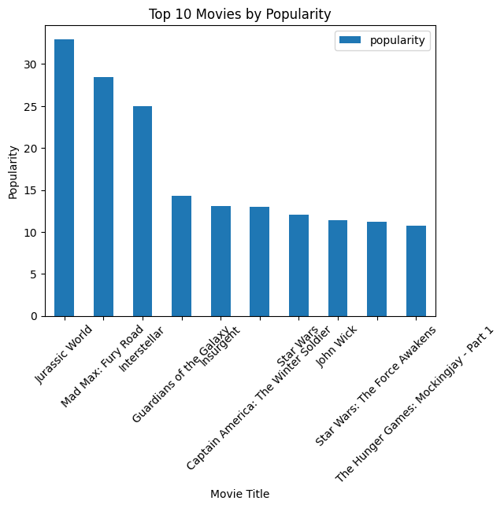

```python
# Plot the top 10 movies by popularity
top_popularity_movies.plot(kind='bar', x='original_title', y='popularity', title='Top 10 Movies by Popularity')
plt.xlabel('Movie Title')
plt.ylabel('Popularity')
plt.xticks(rotation=45)
plt.show()
```

##### Conclusion:

- High Popularity and High Profit
1. Jurassic World and Star Wars: The Force Awakens are both highly popular and highly profitable, showing a link between popularity and profit.
- High Budget Doesn't Always Mean High Popularity or Profit
1. Movies like The Warrior's Way and Pirates of the Caribbean: On Stranger Tides have large budgets but aren't in the top 10 for popularity or profit.
2. Movies with smaller budgets, like Frozen and The Net, can still be very profitable.

#### Research Question 6: What are the top movies based on viewer rating?

##### print the top 10 movies by viewer rating

```python
# Identify the top 10 movies by viewer rating
top_rated_movies = data[['original_title', 'vote_average']].sort_values(by='vote_average', ascending=False).head(10)

# Display the top 10 movies by viewer rating
print("Top 10 movies in terms of viewer rating:")
print(top_rated_movies)
```

```
Top 10 movies in terms of viewer rating:
                                         original_title  vote_average
3894                      The Story of Film: An Odyssey           9.2
1200                      Black Mirror: White Christmas           8.8
6911                                  Pink Floyd: Pulse           8.7
3690                                  The Art of Flight           8.5
8221  A Personal Journey with Martin Scorsese Throug...           8.5
8839                Dave Chappelle: Killin' Them Softly           8.5
8411                              Queen - Rock Montreal           8.5
4178                           The Shawshank Redemption           8.4
2334                     Rush: Beyond the Lighted Stage           8.4
609       The Jinx: The Life and Deaths of Robert Durst           8.4
```

##### Convert budget and revenue to numeric values (if not already)

```python
# Convert budget and revenue to numeric values (if not already)

convert_to_numeric(data, ['budget', 'revenue'])
```

```
Columns converted to numeric: ['budget', 'revenue']
```

##### Identify the top 10 movies by budget

```python
# Identify the top 10 movies by budget
display_top_movies_by_column(data, 'budget')
```

```
Top 10 movies in terms of budget:
                                   original_title     budget
2244                            The Warrior's Way  425000000
3375  Pirates of the Caribbean: On Stranger Tides  380000000
7387     Pirates of the Caribbean: At World's End  300000000
14                        Avengers: Age of Ultron  280000000
6570                             Superman Returns  270000000
4411                                  John Carter  260000000
1929                                      Tangled  260000000
7394                                 Spider-Man 3  258000000
5508                              The Lone Ranger  255000000
1389       Harry Potter and the Half-Blood Prince  250000000
```

##### Calculate profit then Sort by profit in descending order and Display the top 10

```python
sort_and_display_top_movies_by_profit(data)
```

[output not shown]

```
Top 10 movies in terms of profit:
                                    original_title      profit
1386                                        Avatar  2544505847
3                     Star Wars: The Force Awakens  1868178225
5231                                       Titanic  1645034188
0                                   Jurassic World  1363528810
4                                        Furious 7  1316249360
4361                                  The Avengers  1299557910
3374  Harry Potter and the Deathly Hallows: Part 2  1202817822
14                         Avengers: Age of Ultron  1125035767
5422                                        Frozen  1124219009
8094                                       The Net  1084279658
```

##### Plot the top 10 movies by viewer rating

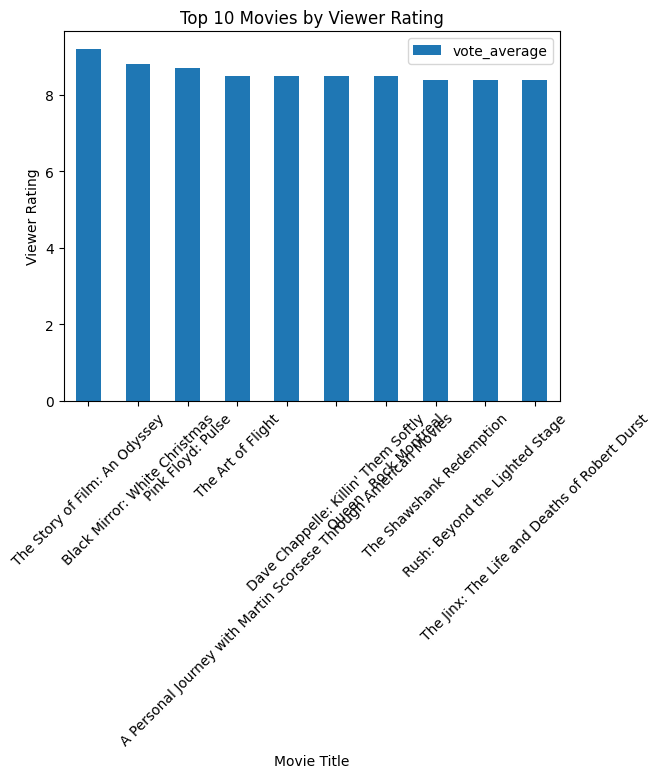

```python
# Plot the top 10 movies by viewer rating
top_rated_movies.plot(kind='bar', x='original_title', y='vote_average', title='Top 10 Movies by Viewer Rating')
plt.xlabel('Movie Title')
plt.ylabel('Viewer Rating')
plt.xticks(rotation=45)
plt.show()
```

##### Average runtime of the highest rated movies:

```python
high = data.nlargest(10, ['vote_average'])

# Calculate the average runtime of the highest rated movies
average_runtime = high['runtime'].mean()

# Print the average runtime
print(f"Average runtime of the highest rated movies: {average_runtime} minutes")
```

```
Average runtime of the highest rated movies: 210.8 minutes
```

##### Conclusion:

> - Average runtime of the highest rated movies is 210.8 minutes
> - High viewer ratings do not always correlate with high budgets or profits. -High budget movies often make high profits but not necessarily high viewer ratings. -The most profitable movies are not always the top-rated ones, showing different factors drive profitability and viewer appreciation.

#### Research Question 7: What are the most common keywords?

##### Split the keywords column and count occurrences

```python
# Split the cast column and count occurrences

words_split = pd.Series(keywords_data['keywords'].str.split('|', expand=True).stack())

# Count occurrences
keywords_count  = words_split.value_counts()
print(keywords_count.head(10))
```

```
woman director      408
independent film    393
based on novel      278
sex                 272
sport               215
murder              204
musical             169
biography           168
new york            162
suspense            159
Name: count, dtype: int64
```

##### Plot the most common keywords using bar kind

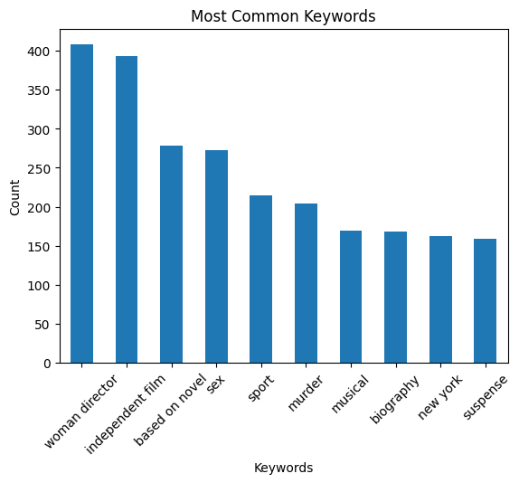

```python
# Plot the most common keywords
top_keywords = keywords_count.head(10)
top_keywords.plot(kind='bar', title='Most Common Keywords')
plt.xlabel('Keywords')
plt.ylabel('Count')
plt.xticks(rotation=45)
plt.show()
```

##### Plot the most common keywords using barh kind

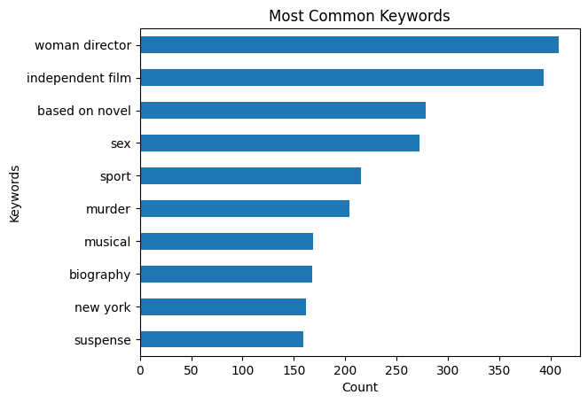

```python
# Plot the most common keywords using a horizontal bar plot
top_keywords = keywords_count.head(10)
top_keywords.plot(kind='barh', title='Most Common Keywords')
plt.xlabel('Count')
plt.ylabel('Keywords')
plt.gca().invert_yaxis()  # Invert y-axis to have the most common keyword at the top
plt.show()
```

#### Research question 8: Is the budget related to a higher average vote?

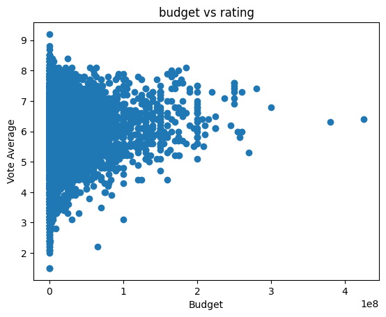

```python
from importlib import reload
plt=reload(plt)
plt.scatter(x=data['budget'], y=data['vote_average'])
plt.title("budget vs rating")
plt.xlabel("Budget")
plt.ylabel('Vote Average')
plt.show()
```

##### Conlusions:

> 1. The chart shows that spending more money on making a movie doesn't always mean it will get better ratings.
> 2. Movies with both high and low budgets often get similar ratings, showing that money isn't the only thing that matters.
> 3. There are expensive movies with good ratings and cheap movies with good ratings, proving that many different things can make a movie popular or not.

#### Research Question 9: what's the correlation between runtime and each of popularity, rating, popularity?

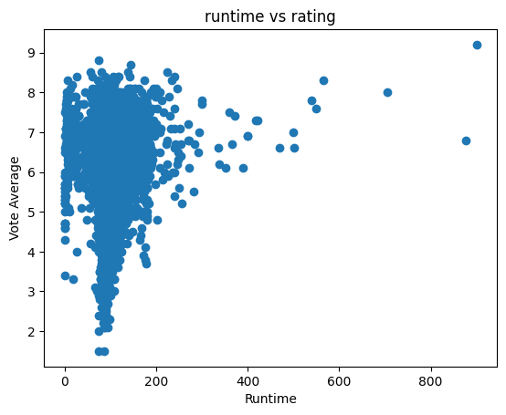

```python
plt.scatter(x=data['runtime'], y=data['vote_average'])
plt.title("runtime vs rating")
plt.xlabel("Runtime")
plt.ylabel('Vote Average')
plt.show()
```

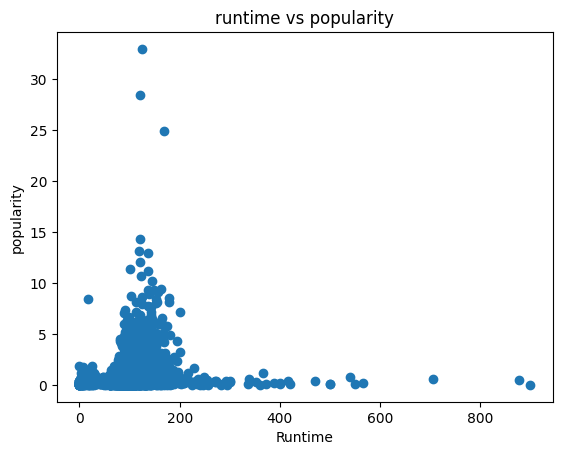

```python
plt.scatter(x=data['runtime'], y=data['popularity'])
plt.title("runtime vs popularity")
plt.xlabel("Runtime")
plt.ylabel('popularity')
plt.show()
```

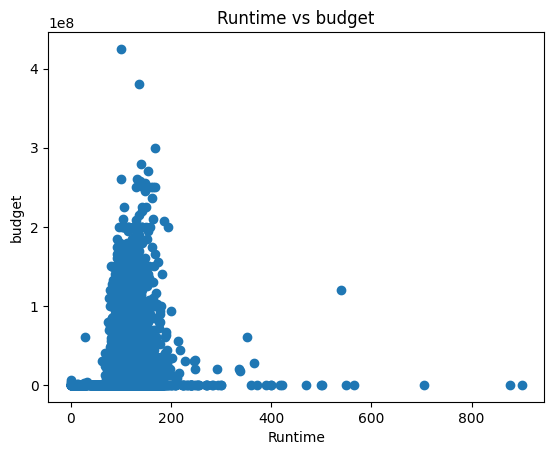

```python
plt.scatter(x=data['runtime'], y=data['budget'])
plt.title("Runtime vs budget")
plt.xlabel("Runtime")
plt.ylabel('budget')
plt.show()
```

#### Research Question 10: Who are the most successful directors?

```
Most successful director is the one who generated the most revenue
```

```python
dir_rev = data.groupby(['director']).sum()['revenue'].nlargest(10)
dir_rev
```

```
director
Steven Spielberg     9018563772
Peter Jackson        6523244659
James Cameron        5841894863
Michael Bay          4917208171
Christopher Nolan    4167548502
David Yates          4154295625
Robert Zemeckis      3869690869
Chris Columbus       3851491668
Tim Burton           3665414624
Ridley Scott         3649996480
Name: revenue, dtype: int64
```

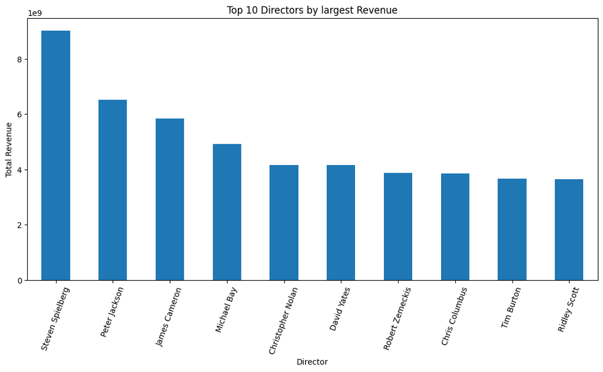

```python
dir_rev.plot(kind = 'bar', figsize=(13,6))
plt.title("Top 10 Directors by largest Revenue")
plt.xticks(rotation=70)
plt.xlabel("Director")
plt.ylabel("Total Revenue")
plt.show()
```

##### Conclusion:

> 1. Steven Spielberg is the most successful director in terms of revenue
> 2. he's followed by Peter Jackson, while James Cameron comes 3rd

#### Research Question 11: How did the runtime of movies change over the years? What Movie has the longest runtime? what movie has the shortest runtime? what's the average movie runtime?

##### Average movie runtime:

```python
# Calculating the average runtime for all movies
average_runtime = data['runtime'].mean()
print("\nAverage Movie Runtime:", average_runtime)
```

```
Average Movie Runtime: 102.46882862734135
```

##### Longest movie:

```python
# Finding the movie with the longest runtime
longest_runtime_movie = data[data['runtime'] == data['runtime'].max()]
print("\nMovie/s with the Longest Runtime:\n", longest_runtime_movie[['original_title', 'runtime']])
```

```
Movie/s with the Longest Runtime:
                      original_title  runtime
3894  The Story of Film: An Odyssey      900
```

##### Shortest movie:

```python
# Finding the movie with the shortest runtime
shortest_runtime_movie = data[data['runtime'] == data['runtime'].min()]
print("\nMovie/s with the Shortest Runtime:\n", shortest_runtime_movie[['original_title', 'runtime']])
```

```
Movie/s with the Shortest Runtime:
                      original_title  runtime
92         Mythica: The Necromancer        0
334                         Ronaldo        0
410                  Anarchy Parlor        0
445   The Exorcism of Molly Hartley        0
486              If There Be Thorns        0
595                       Deep Dark        0
616                    The Outfield        0
1289                      Treehouse        0
1293                       Tim Maia        0
1849                   Spectacular!        0
3329       Grande, grosso e Verdone        0
3794           Toi, moi, les autres        0
3857                       Cell 213        0
3884                         eCupid        0
4063         Madea's Family Reunion        0
4138             A Time for Dancing        0
4829                           Rags        0
4944            How to Fall in Love        0
5216          Madea's Class Reunion        0
5695               Skinwalker Ranch        0
5920         The Food Guide to Love        0
5938                    Go Goa Gone        0
5992               Amiche da morire        0
6040          The Vatican Exorcisms        0
6383       The 12 Dogs of Christmas        0
6552                Quatre Ã©toiles        0
6934                  Jean-Philippe        0
8874                Mission Kashmir        0
```

##### Average movie runtime:

```python
# Analyze how the runtime of movies has changed over the years
# Grouping the data by 'release_year' and calculating the average runtime per year
runtime_by_year = data.groupby('release_year')['runtime'].mean()
```

##### Runtime visualization:

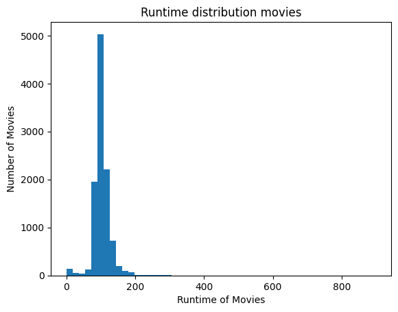

```python
# x-axis
plt.xlabel('Runtime of Movies')
# y-axis
plt.ylabel('Number of Movies')
# Title of the histogram
plt.title('Runtime distribution movies')
# Plot a histogram
plt.hist(data['runtime'], bins = 50)
```

##### Change of runtime over the years:

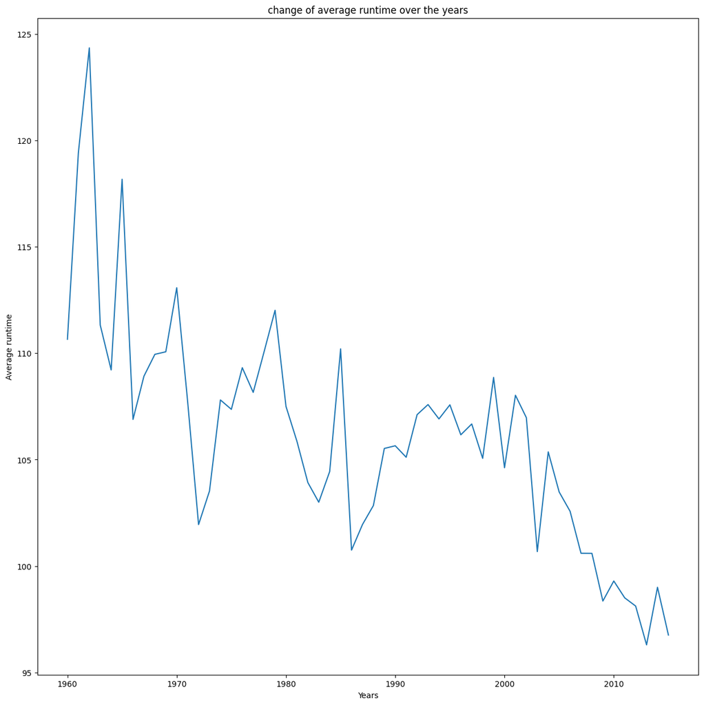

```python
year_runtime = data['runtime'].groupby(data['release_year']).describe()
average_runtime = year_runtime['mean']
f, axs = plt.subplots(figsize=(15,15))
axs.plot(average_runtime)
axs.set_title("change of average runtime over the years")
axs.set_xlabel("Years")
axs.set_ylabel("Average runtime")
plt.show()
```

## Conclusions

[output not shown]

### Data limitations:

1. **Viewer Bias**: Viewer counts vary significantly across movies. Consequently, movies with fewer viewers may show disproportionately high ratings, which could skew perceived quality assessments.
2. **Duration Variability**: The dataset includes movies shorter than 40 minutes, classified as short films. Their inclusion could distort analyses related to runtime statistics and comparisons.
3. **Economic Factors**: The value of money has changed over the years, impacting revenue comparisons. Adjusting for inflation is necessary to accurately assess and compare the financial success of films across different eras.
4. **Incomplete Data**: Missing data in key columns like cast, director, and production companies can limit the depth and accuracy of analysis, particularly if these fields are crucial for specific research questions.
5. **Data Granularity**: The granularity of genre data is compromised by the pipe-separated format in the genres column, which complicates the extraction and accurate counting of unique genres.
6. **Correlation Limitations**: The identified correlations between variables such as popularity and revenue are weak and require more robust statistical analysis to validate any inferred relationships.